1. Dept. of Biology, Institution A, City, Province, Country
2. Environmental Science Centre, Governmental Organisation, City, Province, Country

*Corresponding Author

email: first.author@institutiona.ca (FA)

**Author Contributions:** FA conceived of the study, conducted the analyses, and wrote the original, and revised drafts of the manuscript. SA, and TA, helped with the draft manuscript and revisions and supplied guidance to FA. TA provided the data for the case study, contributed to the revisions, and assisted with the analysis of the case study data.

If I was publishing this as an HTML document and wanted the link to be pretty versus human readable, I would use [this format](https://link_to_archived_release_or_GitHub.com) instead

**Conflict of Interest statement**

No conflicts of interest

**Acknowledgements:** We would like to thank a whole bunch of people.

# Abstract

# Introduction

## And example of adding citations in RMarkdown…

Ecologists have long recognized that some combinations of species are regularly found together, while other combinations occur infrequently (Elton 1946; Cole 1949).

The above format wraps the citation in brackets but if you want to reference the authors by name instead of just as a citation you can use this format instead (i.e., no square brackets around the cite key)

Cole (1949) and Elton (1946) both found that blah blah blah

# Methods

As with Pielou’s Evenness (Pielou & Pielou 1967), Shannon’s diversity index (Shannon 1948)$(H)$ is normally calculated from species abundance values; however, for our purposes it is calculated from the column totals (species richness per sample) using the following equation…

$$H_x = -S[P(i_x) \times ln(P(i_x))]$$

where $x$ denotes which set of values we are using to calculate the index (observed, minimal or maximal), and $P(i_x)$ is the proportion of species that occur in each sample $(i)$.

The above demonstrates both “inline” and “display” math formats. If you look at the Source version you will see that it is simply the number of $ symbols before and after that differentiates between the two. An excellent (and simple) guide on inserting math into your R Markdown documents can be found here:  
https://rpruim.github.io/s341/S19/from-class/MathinRmd.html

# References

Cole, L.C. (1949). The measurement of interspecific association. *Ecology*, 30, 411.

Elton, C. (1946). Competition and the structure of ecological communities. *The Journal of Animal Ecology*, 15, 54.

Pielou, D.P. & Pielou, E.C. (1967). The detection of different degrees of coexistence. *Journal of Theoretical Biology*, 16, 427–437.

Shannon, C.E. (1948). A Mathematical Theory of Communication. *Bell System Technical Journal*, 27, 379–423.

# Tables

**Table 1.** Mean body mass of penguins on different islands over time.

| Island | Year | Mean Body Mass (g) |
| --- | --- | --- |
| Biscoe | 2007 | 4740.909 |
| Biscoe | 2008 | 4628.125 |
| Biscoe | 2009 | 4792.797 |
| Dream | 2007 | 3684.239 |
| Dream | 2008 | 3779.412 |
| Dream | 2009 | 3691.477 |
| Torgersen | 2007 | 3763.158 |
| Torgersen | 2008 | 3856.250 |
| Torgersen | 2009 | 3489.062 |

# Figure Captions

**Figure 1**. Pretty coloured dots about penguins

**Figure 2**. Wow, even prettier plot about penguins that shows stuff

# Figures

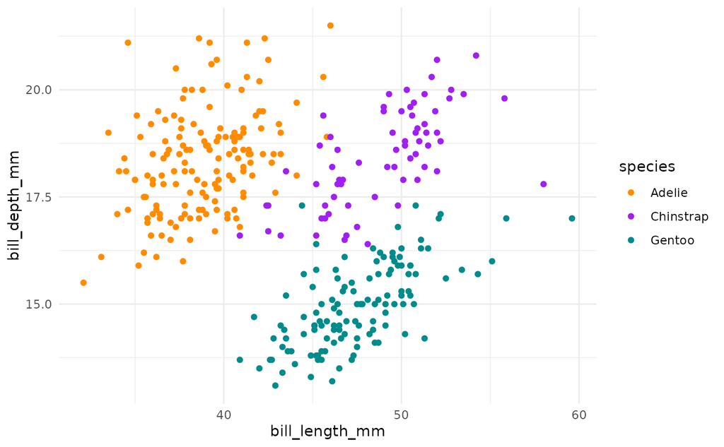

Figure 1.

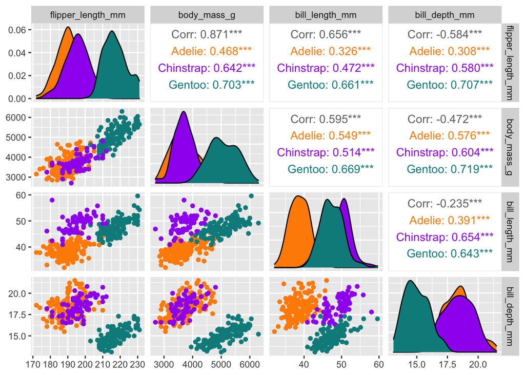

Figure 2.

Figure 3.

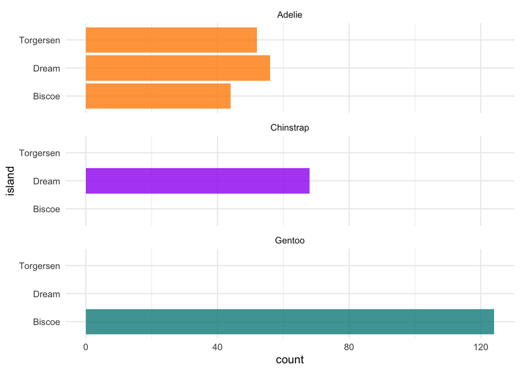

```r
# plot counts of penguins by island and subspecies
ggplot(penguins, aes(x = island, fill = species)) +
  geom_bar(alpha = 0.8) +
  scale_fill_manual(values = c("darkorange","purple","cyan4"),
                    guide = "none") +
  theme_minimal() +
  facet_wrap(~species, ncol = 1) +
  coord_flip()
```